# Homework-2

**NOTE**: Please refer to the syllabus for all information about late penalties, deliverable information, expectations, grading policies, etc.

**DUE DATES**: Due dates can be found on each assignment’s canvas page AND at the bottom of the syllabus

**SUBMISSION**:

- **Part-1:** Tidying data in R and python
  - A template of the directory-tree is provided with the assignment
  - **You need to submit a link to your github classroom repo**
  - **You need to submit a compressed version of the “codes-and-outputs” folder**.
    - That folder should include 12 completed files: `loans.R`, `loans.py`, `loans_r.csv`, `loans_py.csv`,`district.R`, `district.py`, `district_r.csv`, `district_py.csv`, `analytical.R`, `analytical.py`, `analytical_r.csv`, `analytical_py.csv`.
  - Your code should work by pointing back to the data folder one level below where the code is (i.e point at “../data”)
  - **DO NOT SUBMIT THE “data” FOLDER ITSELF**

## HW-2.1: Tidying data in R and Python

### Introduction

The goal of this assignment is to expose students to a real world data-tidying exercise.

Assume you are hired as a data scientist by a bank offering services for its customers such as managing of accounts, offering loans, etc.

The bank was to improve its services but the bank managers had only vague idea of who was a good customer (whom to offer some additional services) and who was a bad customer (whom to watch carefully to minimize the bank losses). Fortunately, the bank stored data about its clients, the accounts (transactions within several months), the loans already granted, the credit cards issued. The bank managers hoped to improve their understanding of customers and seek specific actions to improve services, however, they failed.

Your job is to prepare and analyze this data and use it to help guide the operations of a new bank that the startup you just joined as a Data Scientist is going to open.

### The Data

The data for all of the bank’s operations was contained in an application that used a relational database for data storage, and the data was exported from their system into separate `CSV` files. This is a snaphot dataset, meaning it shows the values that were current at the time of the dataset export.

The data is contained in the `data.zip` file included in this repository. **You must unzip the file**, which will create a `data/` directory inside this repository.

*You should write all of your code and save all outputs into the “codes-and-outputs” folder. Your code should work by pointing back to the data folder, one level below where the code is (i.e point at “../data”)*

There are eight files in the `data/` and below is a description of the contents of each file. You will practice reading in data, cleaning and rearranging the data, making the data tidy, and joining datasets for the purposes of creating a dataset that is ready to be visualized.

**NOTE**: The first column in each file is just called “id”, you should rename it when you load the data-frame. This can be done based on the file name (e.g. in accounts.csv the id column should be renamed account_id, and so one). Notice that some id’s are shared by different files, these can be used as common-keys.

`accounts.csv` contains information about the bank’s accounts.

| Field Name | Description |
| --- | --- |
| `account_id` | Unique record identifier |
| `district_id` | Branch location |
| `date` | Date of account opening |
| `statement_frequency` | The frequency that statements are generated for the account |

`clients.csv` contains information about the bank’s customers. A client (customer) can have several accounts.

| Field Name | Description |
| --- | --- |
| `client_id` | Unique record identifier |
| `gender` | Client’s gender |
| `birth_date` | Client’s birthday |
| `district_id` | Client’s location |

`links.csv` contains information that links customers to accounts, and wether a customer is the owner or a user in a given account.

| Field Name | Description |
| --- | --- |
| `link_id` | Unique record identifier |
| `client_id` | Client identifier |
| `account_id` | Account identifier |
| `type` | Owner or User |

`transactions.csv` contains all of the bank’s transactions.

| Field Name | Description |
| --- | --- |
| `transaction_id` | Unique record identifier |
| `account_id` | Account identifier |
| `date` | Transaction date |
| `type` | Debit or Credit |
| `amount` | Amount of transaction |
| `balance` | Account balance after the transaction is excuted |
| `bank` | The two letter code of the other bank if the transaction is a bank transfer |
| `method` | Method of transaction: can be bank transfer, cash, or credit card |
| `category` | What the transaction was for |

`payment_orders.csv` contains information about orders for payments to other banks via bank transfers. A customer issues an order for payment and the bank executes the payment. These payments should also be reflected in the `transactions.csv` data as debits.

| Field Name | Description |
| --- | --- |
| `order_id` | Unique record identifier |
| `account_id` | Account identifier |
| `recipient_bank` | The two letter code of the bank where the payment is going |
| `recipient_account` | The account number of at the bank where the payment is going to |
| `amount` | Amount of transaction |
| `payment_reason` | What the transaction was for |

`cards.csv` contains information about credit cards issued to clients. Accounts can have more than one credit card.

| Field Name | Description |
| --- | --- |
| `card_id` | Unique record identifier |
| `link_id` | Entry that maps a client to an account |
| `type` | Credit Card product name (Junior, Classic or Gold) |
| `issue_date` | Date the credit card was issued |

`loans.csv` contains information about loans associated with accounts. Only one loan is allowed per account.

[output not shown]

`districts.csv` contains demographic information and characteristics about the districts where customers and branches are located.

| Field Name | Description |
| --- | --- |
| `district_id` | Unique district identifier |
| `name` | District name |
| `region` | Region name |
| `population` | Number of inhabitants |
| `num_cities` | Number of cities |
| `urban_ratio` | Ratio of urban population |
| `avg_salary` | Average salary |
| `entrepreneur_1000` | Number of entrepreneurs per 1,000 inhabitants |
| `municipality_info` | An array with the number of municipalities with the following attributes: * Population < 500 * Population 500-1999 * Population 2000-9999 * Population >= 10000 |
| `unemployment_rate` | An array with the unemployment rate for ’95 and ’96 respectively |
| `commited_crimes` | An array with the number of commited crimes for ’95 and ’96 respectively |

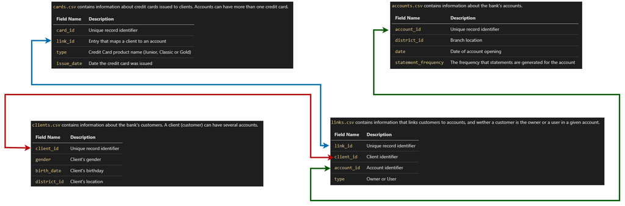

### Assignment: Data cleaning

You need to perform the tasks below in **both** `R` and `Python`. For each task, you need to write two scripts an `.R` script and a `.py` script. **Jupyter notebooks (`.ipynb`) or Rmarkdown (.rmd) are not allowed.** Your scripts must follow these rules and must run on professor/TA machines without any modification:

- No hard coded paths, only relative paths
- Output files must be saved within the same directory “codes-and-outputs”
- The code should be well documented and there should be as many comments as possible

We recommend you use any of the `tidyverse` set of packages in `R` and `pandas` in `Python`.

1. Make the `loans.csv` data tidy. You must account for **all** the information contained in each record (row) and that should be in their own field. Remember, for a dataset to be considered tidy, it must meet the following criteria:
   - Each variable must have its own column
   - Each observation must have its own row
   - Each type of observational unit forms a table

   The scripts that perform this task are called `loans.R` and `loans.py`. The scripts will produce `CSV` files called `loans_r.csv` and `loans_py.csv`.
2. Make the `district.csv` data tidy. You must account for all the information contained in each record (row).

   The scripts that perform this task are called `district.R` and `district.py`. The scripts will produce `CSV` files called `district_r.csv` and `district_py.csv`.
3. Build an *analytical dataset* by combining (joining) the data from the different tables as you see fit, which will be used for the purposes of exploratory data analysis, visualization and reporting. The unit of analysis is the *account*. This dataset must contain the following information for each *account* using the following field names:
   - `account_id`: Account number
   - `district_name`: Name of the district where the account is
   - `open_date`: Date when account was opened
   - `statement_frequency`: The frequency that statements are generated for the account
   - `num_customers`: The total number of clients associated with the account (owner and users)
   - `credit_cards`: Number of credit cards for an account or zero if none
   - `loan`: T/F if the account has a loan
   - `loan_amount`: The amount of the loan if there is one, `NA` if none
   - `loan_payments`: The amount of the loan payment if there is one, `NA` if none
   - `loan_term`: The duration of loan in months, `NA` if none
   - `loan_status`: The status of the loan (current or expired), `NA` if none
   - `loan_default`: T/F if the loan is in default, or `NA` if none
   - `max_withdrawal`: Maximum amount withdrawn for the account
   - `min_withdrawal`: Minimum amount withdrawn for the account
   - `cc_payments`: Count of credit payments for the account for all cards
   - `max_balance`: Maximum balance in the account
   - `min_balance`: Minimum balance in the account

The scripts that perform this task are called `analytical.R` and `analytical.py`. The scripts will produce `CSV` files called `analytical_r.csv` and `analytical_py.csv`.